# Reproducible Research Demo

## or: What Does This Code Do Again?

#### *Friday, 17 July, 2015*

Ben Chan

CHSE  
chanb@ohsu.edu

Stephanie Renfro

CHSE  
renfrst@ohsu.edu

Thomas Meath

CHSE  
meath@ohsu.edu

## Purpose

This work was inspired by the following email from Farmer Ben.

> From: Ben Chan  
> Sent: Thursday, June 11, 2015 4:04 PM  
> To: Stephanie Renfro  
> Subject: What to feed chicks

> Hello,

> I’m receiving 20 baby chicks next month. Can you help me decide what to feed them? I’m choosing between the following four diets:
> 1. Grower diet
> 2. Layer diet
> 3. Breeder diet
> 4. High cluckage diet

> Thanks, Ben

> Ben Chan, Farmer and Research Associate  
> OHSU Center for Health Systems Effectiveness  
> Office: 3030 SW Moody | Mail Code: MDYCHSE  
> www.ohsu.edu/chse

## Preliminaries

Start clock to calculate total runtime.

```r
start_program <- proc.time()
```

Load needed packages:

- *data.table* - for faster processing
- *knitr* - for better tables (“kable” function)
- *ggplot2* - for pretty plots
- *knitr* - for better table display

```r
packages <- c("data.table", "ggplot2", "knitr")
sapply(packages, require, character.only=TRUE, quietly=TRUE)
```

```
## data.table    ggplot2      knitr
##       TRUE       TRUE       TRUE
```

Define the CHSE color palette function.

```r
colorPalette <- function () {
  c(rgb(  1,  67, 134, maxColorValue=255),
    rgb(119, 120, 123, maxColorValue=255),
    rgb(139, 184, 234, maxColorValue=255),
    rgb(188, 190, 192, maxColorValue=255),
    rgb( 94, 122, 162, maxColorValue=255),
    rgb(223, 122,  28, maxColorValue=255))
}
```

## Prepare Data

This demo uses [data from an experiment on the effect of diet on early growth of chicks](http://www.inside-r.org/r-doc/datasets/ChickWeight), `ChickWeight`, which comes pre-loaded in any R session. Unfortunately, R does not come pre-loaded with a llama dataset(McConnell 2014).

Let’s take a look at the first few rows:

```r
head(ChickWeight)
```

```
##   weight Time Chick Diet
## 1     42    0     1    1
## 2     51    2     1    1
## 3     59    4     1    1
## 4     64    6     1    1
## 5     76    8     1    1
## 6     93   10     1    1
```

Let’s also print a summary of the data.

*Note, by specifying the option “echo = FALSE”, the resulting output will display, but not the code that generated it.*

```
##      weight           Time           Chick     Diet
##  Min.   : 35.0   Min.   : 0.00   13     : 12   1:220
##  1st Qu.: 63.0   1st Qu.: 4.00   9      : 12   2:120
##  Median :103.0   Median :10.00   20     : 12   3:120
##  Mean   :121.8   Mean   :10.72   10     : 12   4:118
##  3rd Qu.:163.8   3rd Qu.:16.00   17     : 12
##  Max.   :373.0   Max.   :21.00   19     : 12
##                                  (Other):506
```

Convert to data.table for faster processing.

```r
ChickWeight <- data.table(ChickWeight)
```

Just for fun, let’s create a table showing mean weight at times 0, 10, and 21 days, for each of the four diet types.

```r
mean_ChickWeight <- ChickWeight[Time %in% c(0,10,21),
                                list(mean_weight = round(mean(weight), digits=1)),
                                by = list(Diet,Time)]

kable(mean_ChickWeight)
```

| Diet | Time | mean_weight |
| --- | --- | --- |
| 1 | 0 | 41.4 |
| 1 | 10 | 93.1 |
| 1 | 21 | 177.8 |
| 2 | 0 | 40.7 |
| 2 | 10 | 108.5 |
| 2 | 21 | 214.7 |
| 3 | 0 | 40.8 |
| 3 | 10 | 117.1 |
| 3 | 21 | 270.3 |
| 4 | 0 | 41.0 |
| 4 | 10 | 126.0 |
| 4 | 21 | 238.6 |

Create a character variable for `diet`. Use this variable for plotting small multiples.

```r
ChickWeight[, dietChr := sprintf("Diet %d", Diet)]
```

```
##      weight Time Chick Diet dietChr
##   1:     42    0     1    1  Diet 1
##   2:     51    2     1    1  Diet 1
##   3:     59    4     1    1  Diet 1
##   4:     64    6     1    1  Diet 1
##   5:     76    8     1    1  Diet 1
##  ---
## 574:    175   14    50    4  Diet 4
## 575:    205   16    50    4  Diet 4
## 576:    234   18    50    4  Diet 4
## 577:    264   20    50    4  Diet 4
## 578:    264   21    50    4  Diet 4
```

## Growth for Individual Chicks

The following plot illustrates the growth curve for individual chicks from 0 to 21 days.

Colors represent the four diets.

**From this plot, it is difficult to distinguish between the performance of the four diets.**

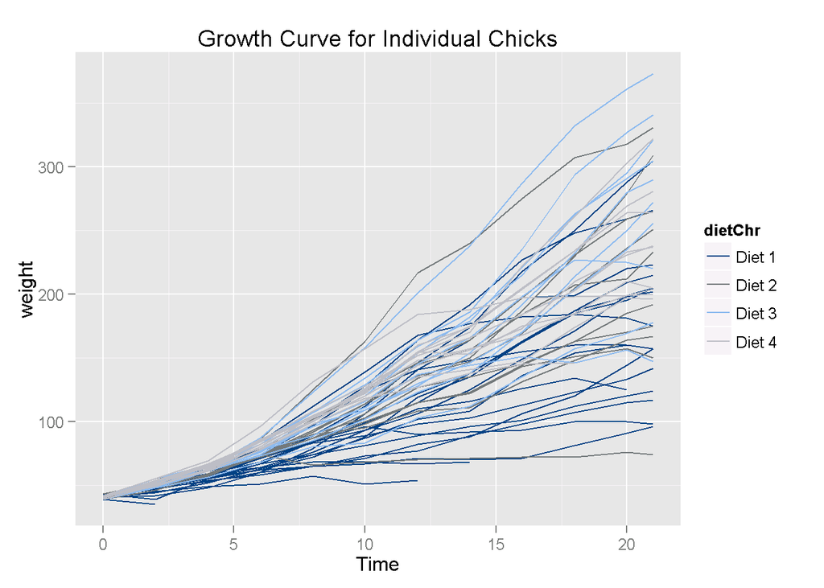

### Individual growth curves

Plot individual chick growth curves using small multiples.

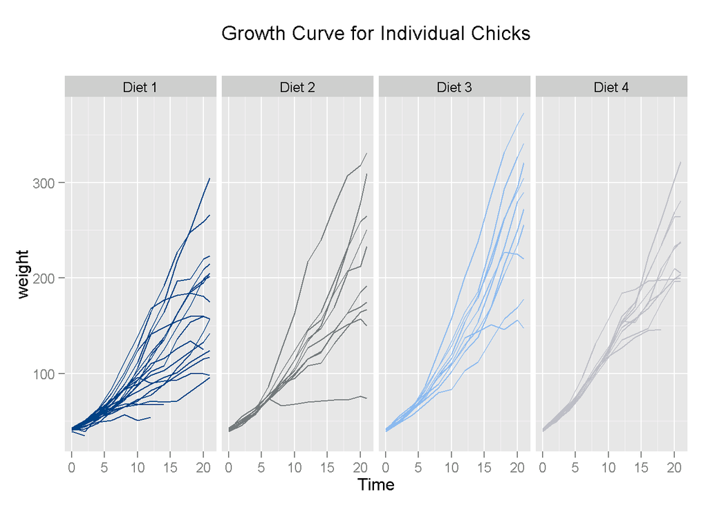

### Fitted growth curves

Plot fitted growth curves using small multiples. Data points are jittered around time value.

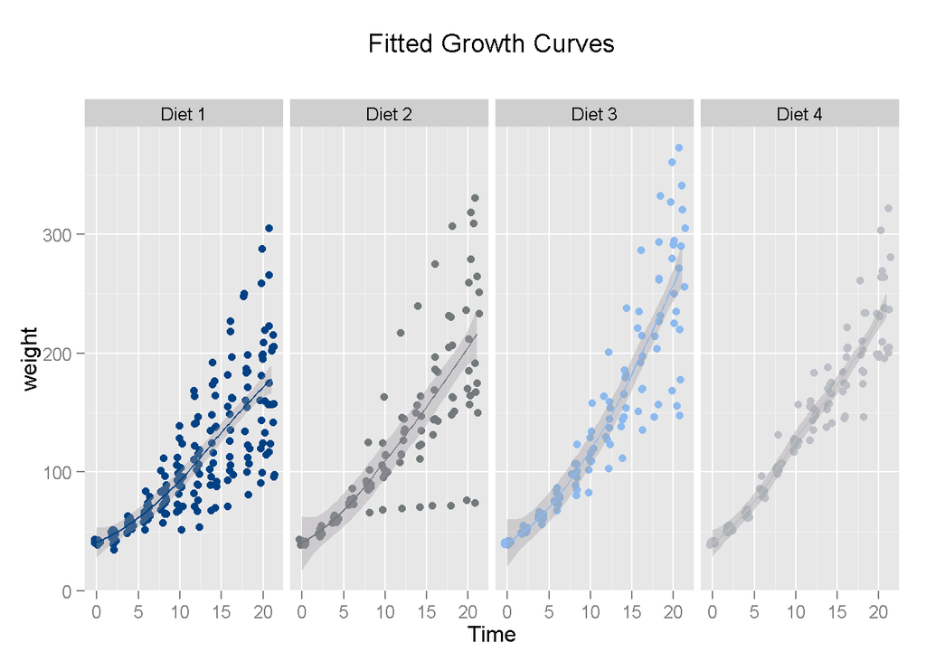

### Final weight density

Plot densities by diet for chicks’ final weights (day 21) using small multiples.

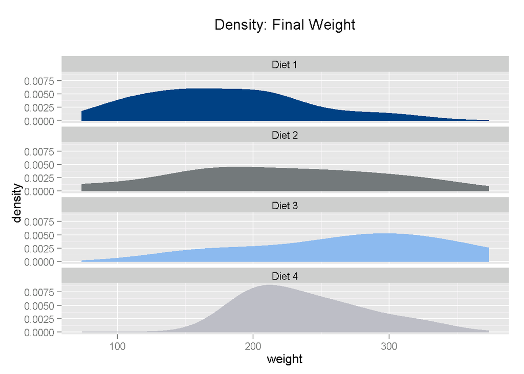

## Wrap Up

Calculate total runtime.

```r
time_program <- proc.time()-start_program
print(paste("Total runtime:", format(time_program[3]/60,digits=3), "minutes"))
```

```
## [1] "Total runtime: 0.119 minutes"
```

Clear memory.

```r
rm(list=ls())
invisible(gc())
```

# Works Cited

McConnell, K. John. 2014. “A Systematic Review of Llama Herding Habits.” *American Journal of Camelids* 21 (2). National Livestock Publishing Group: 124–98.